# Tarea 06

Mario Becerra 124362

23/02/2015

```r
library(gRim)
library(Rgraphviz)
library(png)
library(plyr)
```

**1. Los siguientes son datos de cancer de próstata de Morrison et. al 1973. Los datos son del centro de diagnóstico (X1), grado nuclear (X2) y supervivencia (X3).**

X2 Maligno Maligno Beningno Benigno X1/X3 no sobrevive sobrevive no sobrevive sobrevive Boston 35 59 47 112 Glanmorgan 42 77 26 76

**1.1 Construye un modelo no dirigido que incluya todos los datos (aprende la estructura usando la función stepwise).**

```r
df<-expand.grid(Centro=c('Boston', 'Glanmorgan'), Grado=c('Maligno', 'Benigno'), sup=c( 'Sob', 'NS'))

rep.row <- function(r, n){
  colwise(function(x) rep(x, n))(r)
}

diag<-rbind(
rep.row(df[1,],59),
rep.row(df[2,],77),
rep.row(df[3,],112),
rep.row(df[4,],76),
rep.row(df[5,],35),
rep.row(df[6,],42),
rep.row(df[7,],47),
rep.row(df[8,],26))

head(diag)
```

```
##   Centro   Grado sup
## 1 Boston Maligno Sob
## 2 Boston Maligno Sob
## 3 Boston Maligno Sob
## 4 Boston Maligno Sob
## 5 Boston Maligno Sob
## 6 Boston Maligno Sob
```

```r
tail(diag)
```

```
##         Centro   Grado sup
## 469 Glanmorgan Benigno  NS
## 470 Glanmorgan Benigno  NS
## 471 Glanmorgan Benigno  NS
## 472 Glanmorgan Benigno  NS
## 473 Glanmorgan Benigno  NS
## 474 Glanmorgan Benigno  NS
```

```r
table(diag)
```

```
## , , sup = Sob
##
##             Grado
## Centro       Maligno Benigno
##   Boston          59     112
##   Glanmorgan      77      76
##
## , , sup = NS
##
##             Grado
## Centro       Maligno Benigno
##   Boston          35      47
##   Glanmorgan      42      26
```

Modelo:

```r
m_init <- dmod(~.^1 , data = diag)
m_ad <- stepwise(m_init, criterion = 'aic', details = T,
                     direction = 'forward', type = 'unrestricted')
```

```
## STEPWISE:
##  criterion: aic ( k = 2 )
##  direction: forward
##  type     : unrestricted
##  search   : all
##  steps    : 1000
## . FORWARD: type=unrestricted search=all, criterion=aic(2.00), alpha=0.00
## . Initial model: is graphical=TRUE is decomposable=TRUE
##   change.AIC  -11.3282 Edge added: Centro Grado
##   change.AIC   -1.6195 Edge added: sup Grado
```

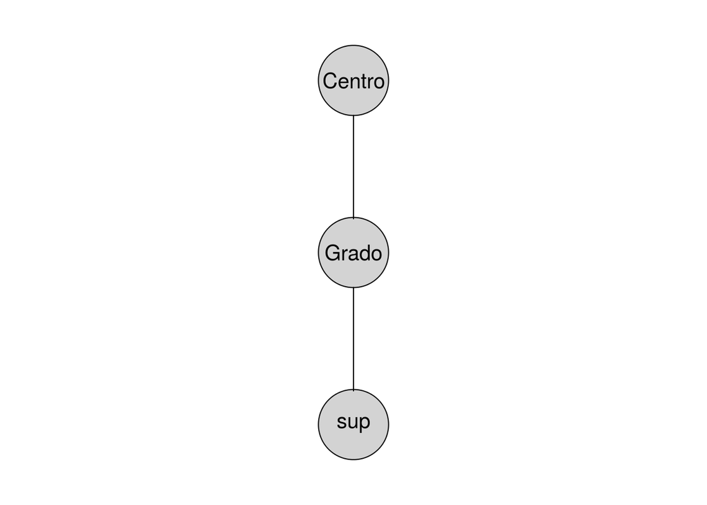

```r
plot(m_ad)
```

**1.2 Obtén las probabilidades ajustadas (usa *$fit$fit*).**

```r
m_ad$fit$fit
```

```
## , , sup = Sob
##
##             Grado
## Centro         Maligno   Benigno
##   Boston      60.01878 114.52874
##   Glanmorgan  75.98122  73.47126
##
## , , sup = NS
##
##             Grado
## Centro         Maligno   Benigno
##   Boston      33.98122  44.47126
##   Glanmorgan  43.01878  28.52874
```

**1.3 Podemos ajustar modelos log-lineales usando modelos lineales generalizados. Para esto, ajusta el modelo correspondiente a la gráfica usando la función glm con familia poisson. Compara las probabilidades ajustadas con las obtenidas en el punto anterior.**

```r
df$Times<-NA
df[1,4]<-59
df[2,4]<-77
df[3,4]<-112
df[4,4]<-76
df[5,4]<-35
df[6,4]<-42
df[7,4]<-47
df[8,4] <- 26

mod <- glm(formula = Times ~ Centro + Grado + sup, family = poisson, data = df)
summary(mod)
```

```
##
## Call:
## glm(formula = Times ~ Centro + Grado + sup, family = poisson,
##     data = df)
##
## Deviance Residuals:
##       1        2        3        4        5        6        7        8
## -2.2177   1.0831   1.6720  -0.7991  -0.1638   1.7928   0.4343  -2.1431
##
## Coefficients:
##                  Estimate Std. Error z value Pr(>|z|)
## (Intercept)       4.35301    0.08669  50.216  < 2e-16 ***
## CentroGlanmorgan -0.13523    0.09207  -1.469   0.1419
## GradoBenigno      0.20323    0.09234   2.201   0.0277 *
## supNS            -0.77011    0.09876  -7.798 6.29e-15 ***
## ---
## Signif. codes:  0 '***' 0.001 '**' 0.01 '*' 0.05 '.' 0.1 ' ' 1
##
## (Dispersion parameter for poisson family taken to be 1)
##
##     Null deviance: 89.970  on 7  degrees of freedom
## Residual deviance: 17.548  on 4  degrees of freedom
## AIC: 72.15
##
## Number of Fisher Scoring iterations: 4
```

**2. Vimos en una tarea anterior que la única indicación de dependencia entre aceptación y género estaba en un departamento particular (dept A). Construye entonces dos modelos log-lineales: uno para el departamento A y otro para el resto. Explica por qué usar dos modelos es mejor para uno solo para entender estos datos.**

Preparando los dataframes para cada modelo: *ad1* será el modelo para el departamento A y *ad2* para los demás.

```r
ad <- read.csv('admisiones.csv')
ad1 <- ad[ad[,4]=='A',-1]
ad2 <- ad[ad[,4]!='A',-1]
ad1$Dept <- factor(ad1$Dept)
ad2$Dept <- factor(ad2$Dept)
```

Departamento A:

```r
m_DepA1 <- dmod(~.^1 , data = ad1)
net_DepA1 <- stepwise(m_DepA1, criterion = 'aic', details = T,
                     direction = 'forward', type = 'unrestricted')
```

```
## STEPWISE:
##  criterion: aic ( k = 2 )
##  direction: forward
##  type     : unrestricted
##  search   : all
##  steps    : 1000
## . FORWARD: type=unrestricted search=all, criterion=aic(2.00), alpha=0.00
## . Initial model: is graphical=TRUE is decomposable=TRUE
##   change.AIC  -17.0540 Edge added: Admit Gender
```

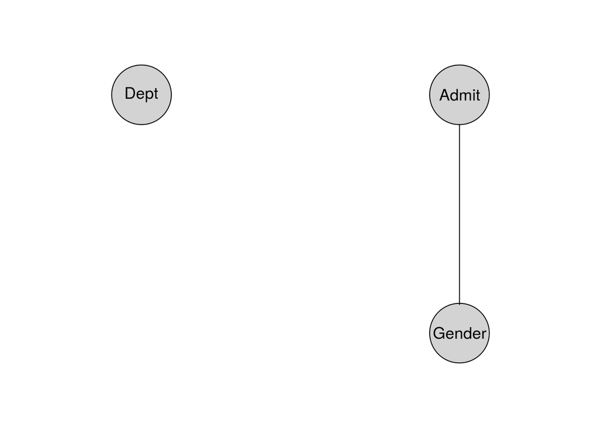

```r
plot(net_DepA1)
```

Los demás:

```r
m_DepTodos1 <- dmod(~.^1 , data = ad2)
net_DepTodos1 <- stepwise(m_DepTodos1, criterion = 'aic', details = T,
                     direction = 'forward', type = 'unrestricted')
```

```
## STEPWISE:
##  criterion: aic ( k = 2 )
##  direction: forward
##  type     : unrestricted
##  search   : all
##  steps    : 1000
## . FORWARD: type=unrestricted search=all, criterion=aic(2.00), alpha=0.00
## . Initial model: is graphical=TRUE is decomposable=TRUE
##   change.AIC -745.4387 Edge added: Gender Dept
##   change.AIC -528.7766 Edge added: Admit Dept
```

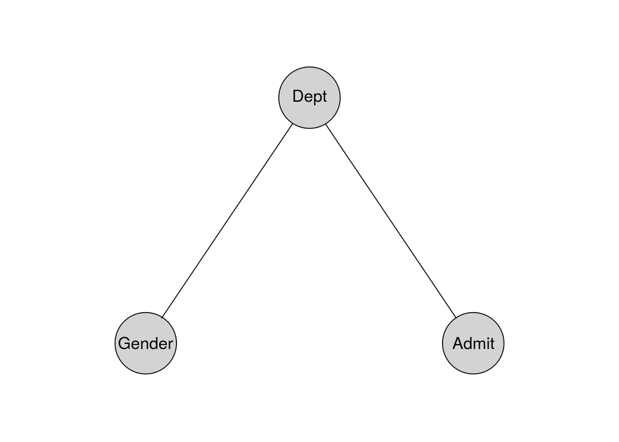

```r
plot(net_DepTodos1)
```

Conviene usar dos modelos distintos porque, como se puede ver en las gráficas de los modelos aprendidos, y como ya habíamos notado antes, la admisión en el departamento A parece sí depender del género mientras que en los demás no. Se puede ver en las gráficas que para el departamento A no existe relación entre el departamento y las variables *Admit* y *Gender*.

Convendría ver la fuerza del arco de cada modelo, para esto, aumentamos el valor de la penalización *k*, el cual, si es más grande, muestra las relaciones más fuertes en las gráficas.

```r
m_DepA2 <- dmod(~.^1 , data = ad1)
net_DepA2 <- stepwise(m_DepA2, k = 4*log(nrow(ad1)), details = T,
                     direction = 'forward', type = 'unrestricted')
```

```
## STEPWISE:
##  criterion: aic ( k = 27.35 )
##  direction: forward
##  type     : unrestricted
##  search   : all
##  steps    : 1000
## . FORWARD: type=unrestricted search=all, criterion=aic(27.35), alpha=0.00
## . Initial model: is graphical=TRUE is decomposable=TRUE
```

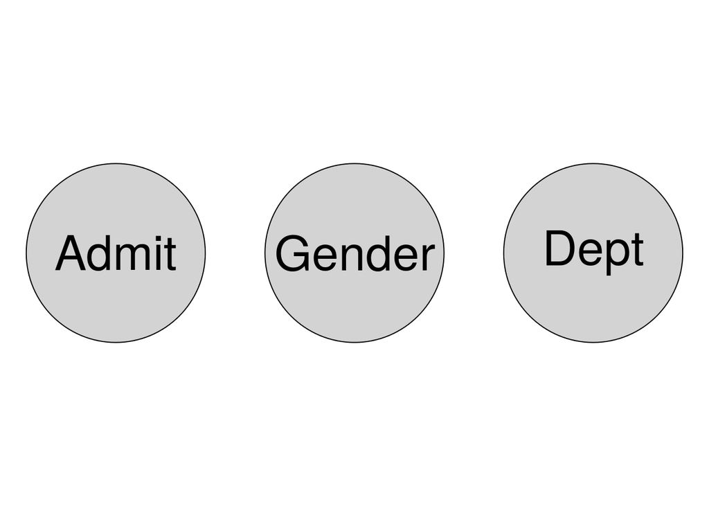

```r
plot(net_DepA2)
```

```r
m_DepTodos2 <- dmod(~.^1 , data = ad2)
net_DepTodos2 <- stepwise(m_DepTodos2, k = 4*log(nrow(ad2)), details = T,
                     direction = 'forward', type = 'unrestricted')
```

```
## STEPWISE:
##  criterion: aic ( k = 32.75 )
##  direction: forward
##  type     : unrestricted
##  search   : all
##  steps    : 1000
## . FORWARD: type=unrestricted search=all, criterion=aic(32.75), alpha=0.00
## . Initial model: is graphical=TRUE is decomposable=TRUE
##   change.AIC -622.4508 Edge added: Gender Dept
##   change.AIC -405.7887 Edge added: Admit Dept
```

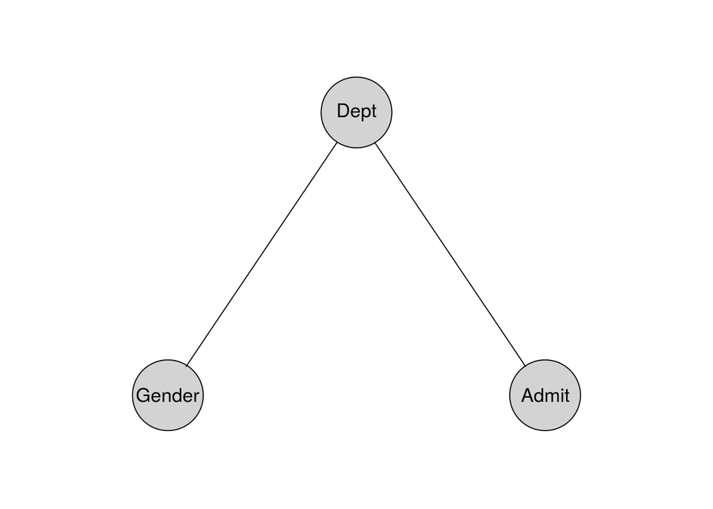

```r
plot(net_DepTodos2)
```

Notamos que con mayor penalización, la relación entre *Gender*, *Admit* y *Dept* se rompe en el departamento A mientras que se mantiene en los demás; pero esta relación es de dependencia condicional, es decir, dado el departamento, el género es independiente de la aceptación en la universidad.

**3. Implementa el algoritmo de Modas Condicionales Iteradas para imágenes binarias que vimos en clase.** **3.1 Construye una frase o dibujo en blanco y negro (puedes usar Word Art) y guardala como imagen (ej. jpeg).** **3.2 Leela en R y conviertela en una matriz binaria con valores {−1,1}.** **3.3 Añade ruido cambiando el signo de cada pixel con probabilidad 0.15.** **3.4 Implementa el algoritmo de modas condicionales iteradas visto en clase para limpiar la imagen (grafica la imagen original, con ruido y después de limpiar).**

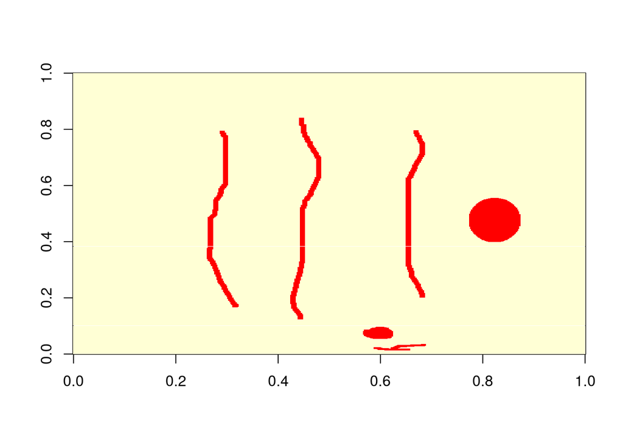

```r
mask<-readPNG('Mask.png')
mask<-mask[,,3]
mask[mask!=0]=-1
mask[mask==0]=1
image(mask)
```

Añadiendo ruido:

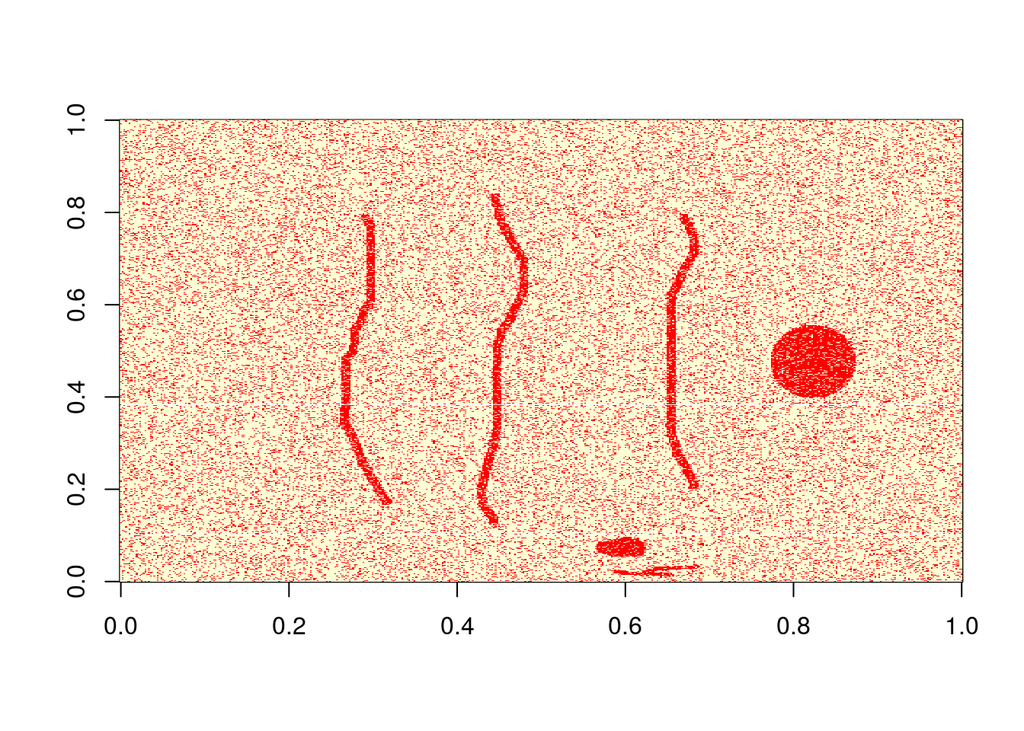

```r
noise<-replicate(ncol(mask), runif(nrow(mask)))
mask[noise<.15] <- -mask[noise<.15]
image(mask)
```